# TASK 5 网络结构的描述统计量

狗熊会

对于网络数据来说，进行描述统计也是非常重要的。如何描述一个网络，网络数据的描述统计量有哪些，这些内容我们将在本TASK中学习。

任务介绍：这个案例的学习目标包括：

1. 掌握网络结构数据的常用描述统计指标：度、出度、入度，网络密度、中心性指标等；
2. 学习绘制网络度分布直方图；
3. 学习如何根据描述分析指标寻找网络中的核心节点。

### 准备工作

```r
# 清除工作环境
cat("\014");rm(list=ls())
```

```r
# 加载相应的包
library(igraph)
library(igraphdata)
library(sand)
```

### 任务一: 计算网络节点中的度（无向网络）、出度入度（有向网络）

对于无向网络，**节点的度(degree)**就是与一个节点相关联的边的条数。

对于有向网络，节点的度又分为**入度(in-degree)**和**出度(out-degree)**。节点的**出度**是指从给定节点出发的连边的数量，节点的**入度**是指指向给定节点的连边的数量。

在R中用`degree()`计算节点的度。通过改变`degree()`函数中mode的取值可计算不同种类的度。其中，`mode = "all"` 为统计节点的度；`mode = "in"` 为统计有向网络的入度；`mode = "out"` 为统计有向网络的出度。

下面用sand包中的aidsblog数据集举例如何用R计算节点的度以及有向网络的入度和出度。

```r
degree(aidsblog, mode="all")   # 计算节点的度
```

```
##   [1]  1  1  1  1  1  1 43  1  1  1  1 23  1  1  1  1  1  1  1  1  1  1  1  1  1
##  [26]  1  1  1  1  1  1  1  1  1  1  1 16  1  1  1  1  1  1  1  1  1  1  1  1  1
##  [51]  1  1  1  1  1  1  1  1  1  1  1  1  1  1  1  1  1  1  1  1  1  1 19  1  1
##  [76]  1  1  1  1  1  1  1  1  1  1  1  1  1  1  1  1  1  1  1  1  1  1  1  1  1
## [101]  1  1  1  1  1  1  1  1  1  1  1  1  1  1  1  1  1 26  1  1  1  2  2  2  3
## [126]  4  6  2  5  2  2  2  2 18  2  2  2  2  3  4  3 18 36  2  3  2
```

```r
degree(aidsblog, mode="in")    # 计算入度
```

```
##   [1] 1 1 1 1 1 1 1 1 1 1 1 1 1 1 1 1 1 1 1 1 1 1 1 1 1 1 1 1 1 1 1 1 1 1 1 1 1
##  [38] 1 1 1 1 1 1 1 1 1 1 1 1 1 1 1 1 1 1 1 1 1 1 1 1 1 1 1 1 1 1 1 1 1 1 1 1 1
##  [75] 1 1 1 1 1 1 1 1 1 1 1 1 1 1 1 1 1 1 1 1 1 1 1 1 1 1 1 1 1 1 1 1 1 1 1 1 1
## [112] 1 1 1 1 1 1 1 1 1 1 2 2 2 3 4 6 2 5 2 2 2 2 2 2 2 2 2 3 4 3 2 3 2 3 2
```

```r
degree(aidsblog, mode="out")   # 计算出度
```

```
##   [1]  0  0  0  0  0  0 42  0  0  0  0 22  0  0  0  0  0  0  0  0  0  0  0  0  0
##  [26]  0  0  0  0  0  0  0  0  0  0  0 15  0  0  0  0  0  0  0  0  0  0  0  0  0
##  [51]  0  0  0  0  0  0  0  0  0  0  0  0  0  0  0  0  0  0  0  0  0  0 18  0  0
##  [76]  0  0  0  0  0  0  0  0  0  0  0  0  0  0  0  0  0  0  0  0  0  0  0  0  0
## [101]  0  0  0  0  0  0  0  0  0  0  0  0  0  0  0  0  0 25  0  0  0  0  0  0  0
## [126]  0  0  0  0  0  0  0  0 16  0  0  0  0  0  0  0 16 33  0  0  0
```

### 任务二: 学习绘制网络节点的度分布直方图，并解读

度是指网络中与一个节点相关联的边的条数，度分布就是整个网络中各个点的度数量的频数分布。

度分布对于真实网络（如社交网络、引文网等）研究非常的重要。真实网络中的度分布往往是右偏的，即有大量的度比较小的节点，少量度比较大的节点。这样的网络被称为**无标度网络**。

下面用aidsblog数据集举例如何用R绘制网络节点的度分布直方图。

```r
degree<-degree(aidsblog,mode="all")    # 统计节点的度
table(degree)                          # 计数
```

```
## degree
##   1   2   3   4   5   6  16  18  19  23  26  36  43
## 116  14   4   2   1   1   1   2   1   1   1   1   1
```

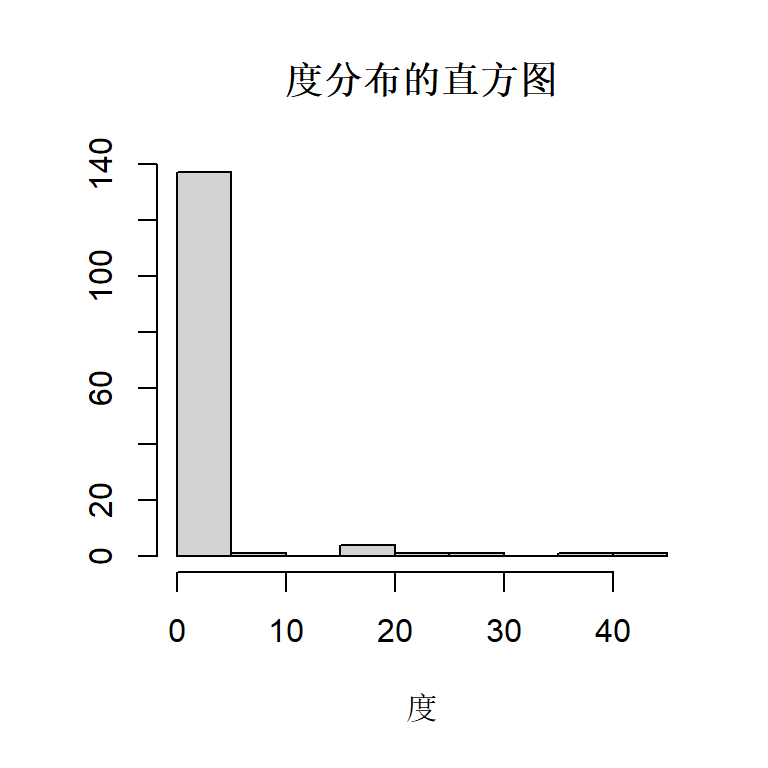

```r
hist(degree, main = "度分布的直方图", xlab = "度", ylab = "")     # 绘制直方图
```

通过观察上图可以看出，极大部分节点的度都处于一个非常低的水平，只有极少数节点的度较大。

### 任务三: 学习网络密度的概念，并计算网络密度

网络密度用于刻画网络中节点间相互连边的密集程度，网络密度越大说明网络越复杂。网络密度的计算公式为：

$$网络密度 = \frac{实际边数}{理论边数}$$

$理论边数$即可容纳边数的上限。

无向网络的网络密度计算公式如下：

$$无向网络密度 = \frac{实际边数}{理论边数} = \frac{N}{{C_n}^2}$$
n表示节点数量；N表示边数。

在R中我们用`graph.density()`函数来计算网络密度。

用sand包中的elist.lazega数据集为例用R计算网络密度。通过计算得出该网络的网络密度为0.1825397。

```r
g.lazega <- graph.data.frame(elist.lazega, directed = 'FALSE', vertices = v.attr.lazega)
# 网络密度
graph.density(g.lazega)
```

```
## [1] 0.1825397
```

使用公式手动进行计算得到该网络的网络密度为0.1825397，与R计算得结果相同。

```r
#用公式计算网络密度
n <- length(V(g.lazega))
N <- length(E(g.lazega))
density <- N/choose(n, 2)
density
```

```
## [1] 0.1825397
```

### 任务四：网络节点的中心性指标

本任务我们需要学习网络节点的中心性指标，掌握其概念及计算方法

#### 1. 概念及计算方法

**节点中心性（node centrality）**即，采用某种定量的方法对每个节点处于网络中心地位的程度进行刻画，从而来描述整个网络是否存在核心，以及存在什么样的核心。度量节点中心性较常用的指标为**度中心性（degree centrality，DC）**以及**接近中心性（closeness centrality，CC）**。

##### (1) 度中心性（degree centrality，DC）

**度中心性**衡量的是节点对促进网络中传播过程发挥的过程，计算公式如下：

$$C_{_D}(i) = \frac{k_i}{N-1}$$

$k_i$表示第$i$个节点的度；$N$为节点总数，$N-1$将度量归一化。

##### (2) 接近中心性（closeness centrality，CC）

**接近中心性**度量的思想是：如果一个节点和其它很多节点都很“接近”，则节点处与网络的中心位置，计算公式如下：

$$C_{_{Cl}}(i) = \frac{N-1}{\sum\nolimits_{j}{dist(i,j)}}$$

其中$dist(i,j)$是节点$i,j$的捷径距离，乘$N-1$将该度量归一化到$[0,1]$区间。

（注：还有很多其他节点中心性的度量指标，这里只介绍度中心性和接近中心性，感兴趣的同学可以查阅相关资料，如：Eric D.Kolacayk等人编写的《Statistical Analysis of Network Data with R》等等。）

#### 2. 运用R语言进行计算

本节我们通过R语言计算上述度量节点中心性的指标。用R中sand包的数据集aidsblog作为例子，将介绍`igraph`包中的`degree()`,`closeness()`函数来展示中心性的生成方法。

##### (1) 度中心性 degree()

度中心性`degree()`，参数中:

1. mode = ’in’点入度；’out’为出度；’all’中心度（无向）；
2. normalized = ‘T’,表示计算相对度中心性，即1(1)中公式所示的度量方法。

```r
degree(aidsblog, mode='all', normalized = T)  #度中心性
```

```
##   [1] 0.006896552 0.006896552 0.006896552 0.006896552 0.006896552 0.006896552
##   [7] 0.296551724 0.006896552 0.006896552 0.006896552 0.006896552 0.158620690
##  [13] 0.006896552 0.006896552 0.006896552 0.006896552 0.006896552 0.006896552
##  [19] 0.006896552 0.006896552 0.006896552 0.006896552 0.006896552 0.006896552
##  [25] 0.006896552 0.006896552 0.006896552 0.006896552 0.006896552 0.006896552
##  [31] 0.006896552 0.006896552 0.006896552 0.006896552 0.006896552 0.006896552
##  [37] 0.110344828 0.006896552 0.006896552 0.006896552 0.006896552 0.006896552
##  [43] 0.006896552 0.006896552 0.006896552 0.006896552 0.006896552 0.006896552
##  [49] 0.006896552 0.006896552 0.006896552 0.006896552 0.006896552 0.006896552
##  [55] 0.006896552 0.006896552 0.006896552 0.006896552 0.006896552 0.006896552
##  [61] 0.006896552 0.006896552 0.006896552 0.006896552 0.006896552 0.006896552
##  [67] 0.006896552 0.006896552 0.006896552 0.006896552 0.006896552 0.006896552
##  [73] 0.131034483 0.006896552 0.006896552 0.006896552 0.006896552 0.006896552
##  [79] 0.006896552 0.006896552 0.006896552 0.006896552 0.006896552 0.006896552
##  [85] 0.006896552 0.006896552 0.006896552 0.006896552 0.006896552 0.006896552
##  [91] 0.006896552 0.006896552 0.006896552 0.006896552 0.006896552 0.006896552
##  [97] 0.006896552 0.006896552 0.006896552 0.006896552 0.006896552 0.006896552
## [103] 0.006896552 0.006896552 0.006896552 0.006896552 0.006896552 0.006896552
## [109] 0.006896552 0.006896552 0.006896552 0.006896552 0.006896552 0.006896552
## [115] 0.006896552 0.006896552 0.006896552 0.179310345 0.006896552 0.006896552
## [121] 0.006896552 0.013793103 0.013793103 0.013793103 0.020689655 0.027586207
## [127] 0.041379310 0.013793103 0.034482759 0.013793103 0.013793103 0.013793103
## [133] 0.013793103 0.124137931 0.013793103 0.013793103 0.013793103 0.013793103
## [139] 0.020689655 0.027586207 0.020689655 0.124137931 0.248275862 0.013793103
## [145] 0.020689655 0.013793103
```

##### (2) 接近中心性closeness()

接近中心性`closeness()`，参数中：

乘以n-1来执行标准化

```r
closeness(aidsblog, mode = "all", normalized = T)  #使用无向路径，计算归一化的接近中心度
```

```
##   [1] 0.3033473 0.2272727 0.2272727 0.3033473 0.2788462 0.3033473 0.4341317
##   [8] 0.2772467 0.2788462 0.3033473 0.2788462 0.3571429 0.3033473 0.3033473
##  [15] 0.2772467 0.2788462 0.2705224 0.2772467 0.3033473 0.2788462 0.2772467
##  [22] 0.2788462 0.3222222 0.3222222 0.3033473 0.3033473 0.2636364 0.3033473
##  [29] 0.3033473 0.2772467 0.3222222 0.2772467 0.3222222 0.2636364 0.3222222
##  [36] 0.2788462 0.2935223 0.2636364 0.3033473 0.3033473 0.2636364 0.3033473
##  [43] 0.3222222 0.2788462 0.2772467 0.2272727 0.3033473 0.3222222 0.3033473
##  [50] 0.3222222 0.3033473 0.2788462 0.2772467 0.2272727 0.2636364 0.3222222
##  [57] 0.2636364 0.3033473 0.3222222 0.3222222 0.2272727 0.2772467 0.2272727
##  [64] 0.3033473 0.2272727 0.3222222 0.2788462 0.2636364 0.2636364 0.2272727
##  [71] 0.2636364 0.2705224 0.3825858 0.2636364 0.3033473 0.2636364 0.2636364
##  [78] 0.3033473 0.2705224 0.3033473 0.3033473 0.2636364 0.2636364 0.3222222
##  [85] 0.2772467 0.3222222 0.2788462 0.2788462 0.2272727 0.2705224 0.2705224
##  [92] 0.3033473 0.3222222 0.2772467 0.2772467 0.3222222 0.3033473 0.3033473
##  [99] 0.2636364 0.2788462 0.2272727 0.2636364 0.2705224 0.3033473 0.2636364
## [106] 0.3222222 0.3033473 0.2636364 0.2636364 0.2636364 0.2636364 0.2272727
## [113] 0.3033473 0.3033473 0.2272727 0.3222222 0.2272727 0.3856383 0.2788462
## [120] 0.3033473 0.2788462 0.3111588 0.3325688 0.3580247 0.3452381 0.4005525
## [127] 0.4559748 0.3580247 0.4038997 0.3325688 0.3598015 0.3325688 0.2995868
## [134] 0.3766234 0.3325688 0.3580247 0.3258427 0.3172867 0.3846154 0.3598015
## [141] 0.3670886 0.3698980 0.4738562 0.2989691 0.3625000 0.3159041
```

### 任务五: 网络中的重要节点

本任务我们需要根据描述分析指标寻找网络中的重要节点。我们将根据任务四中衡量网络节点的中心性的两个指标，来寻找重要节点。

我们将选取前5个重要节点，代码如下所示。

```r
# 定义排序函数
sort_value <- function(vec){
  index <- order(vec, decreasing=TRUE)[1:5]
  return(list(index = index,            # 返回对应的节点坐标(index)
              value = vec[index]))      # 以及对应的中心性指标的值
}
```

```r
sort_value(degree(aidsblog, mode = 'all'))             # 运用度中心性
```

```
## $index
## [1]   7 143 118  12  73
##
## $value
## [1] 43 36 26 23 19
```

```r
sort_value(closeness(aidsblog, mode = 'all'))          # 运用接近中心性
```

```
## $index
## [1] 143 127   7 129 126
##
## $value
## [1] 0.003267974 0.003144654 0.002994012 0.002785515 0.002762431
```

根据度中心性度量指标，标号为7、143、118、12和73的节点比较重要，说明这些节点与所有其它节点相联系的程度较高，在网络中的参与度高。

根据接近中心性度量指标，标号为143、127、7、129和126的节点比较重要，说明这些节点与其他节点的“亲密”程度高。

### 课后作业

根据统计论文的合作者网络，完成以下任务：

1. 读入数据并且构建网络；
2. 绘制度分布的直方图，并且做简要解读；
3. 计算度中心性指标。展示排名前十的作者，选择一个作者，了解一下他的研究领域并作简要介绍。